# *Topic Modeling*

## *What is Topic Analysis?*

*Topic analysis (often referred to as topic detection or topic modeling) is a machine learning technique that organizes and understands large collections of text data, by assigning tags or categories according to each individual text’s topic or theme. In other words, they enable you to find patterns and unlock semantic structures behind each of the individual texts.*

*The two most common approaches for **Topic Analysis** with machine learning are **Topic Modeling** and **Topic Classification**.*

*Topic modeling* *is an unsupervised machine learning technique. This means it can infer patterns and cluster similar expressions without needing to define topic tags or train data beforehand. This type of algorithm can be applied quickly and easily, but there’s a downside – they are rather inaccurate.*

*Text classification* *, on the other hand, needs to know the topics of a text before starting the analysis, because you need to tag data in order to train a topic classifier. Although there’s an extra step involved, topic classifiers pay off in the long run and they’re much more precise than clustering techniques.*

## *What is Topic Modeling?*

*Topic Modeling is a process to automatically identify topics present in a text object and to derive hidden patterns exhibited by a text corpus. Topic Models are very useful for multiple purposes, including:*

- *Document clustering*
- *Organizing large blocks of textual data*
- *Information retrieval from unstructured text*
- *Feature selection*

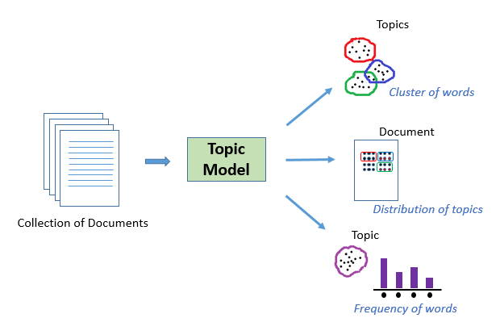

## *Topic Modeling Algorithms*

*There are several algorithms for doing topic modeling. The most popular ones include:*

- *LDA* *– Latent Dirichlet Allocation – The one we’ll be focusing in this tutorial. Its foundations are Probabilistic Graphical Models*
- *LSA or LSI* *– Latent Semantic Analysis or Latent Semantic Indexing – Uses Singular Value Decomposition (SVD) on the Document-Term Matrix. Based on Linear Algebra*
- *NMF* *– Non-Negative Matrix Factorization – Based on Linear Algebra*

*Here are some things all these algorithms have in common:*

- _The number of topics (n*topics) as a parameter. None of the algorithms can infer the number of topics in the document collection.*
- _All of the algorithms have as input the Document-Word Matrix (or Document-Term Matrix). DWM[i][j] = The number of occurrences of word_j in document*i*
- *All of them output 2 matrices: WTM (Word Topic Matrix) and TDM (Topic Document Matrix). The matrices are significantly smaller and the result of their multiplication should be as close as possible to the original DWM matrix.*

## *Latent Dirichlet Allocation (LDA)*

*LDA (short for Latent Dirichlet Allocation) is an unsupervised machine-learning model that takes documents as input and finds topics as output. It builds a topic per document model and words per topic model, modeled as Dirichlet distributions. The model also says in what percentage each document talks about each topic.* *A topic is represented as a weighted list of words. An example of a topic is shown below:*

$flower * 0,2 | rose * 0,15 | plant * 0,09 |…$

*Basic Idea* `Each document can be described by a distribution of topics and each topic can be described by a distribution of words.`

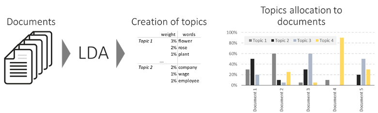

*There are 3 main parameters of the model:*

- *the number of topics*
- *the number of words per topic*
- *the number of topics per document*

*Something we should mention about the implementation is that it has two hyperparameters for training, usually called α (alpha) and β (beta). Knowing what these do is important for using libraries that implement the algorithm.*

- *Alpha* *controls the similarity of documents. A low value will represent documents as a mixture of few topics, while a high value will output document representations of more topics -- making all the documents appear more similar to each other.*
- *Beta* *is the same but for topics, so it controls topic similarity. A low value will represent topics as more distinct by making fewer, more unique words belong to each topic. A high value will have the opposite effect, resulting in topics containing more words in common.*

### *The Algorithm*

- *Go through each document and randomly assign each word in the document to one of k topics (k is chosen beforehand).*
- *For each document d, go through each word w and compute :*
  - *p(topic t | document d)* *: the proportion of words in document d that are assigned to topic t. Tries to capture how many words belong to the topic t for a given document d. Excluding the current word.If a lot of words from d belongs to t, it is more probable that word w belongs to t.*
  - *p(word w| topic t)* *: the proportion of assignments to topic t over all documents that come from this word w. Tries to capture how many documents are in topic t because of word w.*

*LDA represents documents as a mixture of topics. Similarly, a topic is a mixture of words. If a word has high probability of being in a topic, all the documents having w will be more strongly associated with t as well. Similarly, if w is not very probable to be in t, the documents which contain the w will be having very low probability of being in t, because rest of the words in d will belong to some other topic and hence d will have a higher probability for those topic. So even if w gets added to t, it won’t be bringing many such documents to t.*

*Update the probability for the word w belonging to topic t, as* $$p(word w with topic t) = p(topic t | document d) * p(word w | topic t)$$

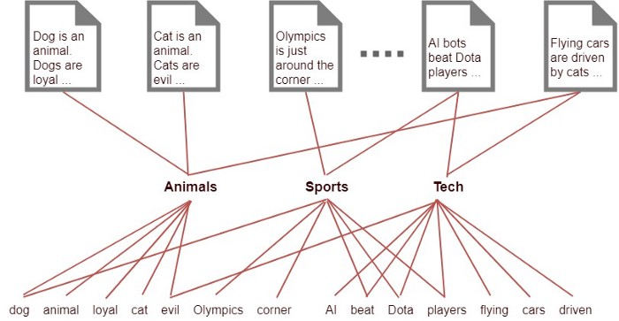

*[Reference](https://iq.opengenus.org/latent-dirichlet-allocation/)*

## *Latent Semantic Analysis (LSA)*

*Latent Semantic Analysis is the ‘traditional' method for topic modeling. It is based on a principle called the distributional hypothesis: words and expressions that occur in similar pieces of text will have similar meanings.*

*Like Naive Bayes, it is based on the word frequencies of the dataset. The general idea is that for every word in each document, you can count the frequency of that word and group together the documents that have high frequencies of the same words.*

*Now, to dive a little bit more into how this is actually done, let's first clarify what is meant by word frequency. The frequency of a word or term in a document is a number that indicates how often a word appears in a document. That's right, these algorithms ignore syntax and semantics such as word order, meaning, and grammar, and just treat every document as an unsorted bag of words.*

*The frequency can be calculated simply by counting — if the word cat appears 10 times in a document, then its frequency is 10. This approach proves to be a bit limited, so tf-idf is normally used. Tf-idf takes into account how common a word is overall (in all documents) vs how common it is in a specific document, so more common words are ranked higher since they are considered a better “representation” of a document even if they are not the most numerous.*

*After doing the word frequency calculation, we are left with a matrix that has a row for every word and a column for every document. Each cell is the calculated frequency for that word in that document. This is the document-term matrix; it relates documents to terms.*

*Hidden inside it is what we want: a **document-topic matrix** and a **term-topic matrix**, which relate documents to topics and terms to topics. These matrices are the ones that show information about the topics of the texts.*

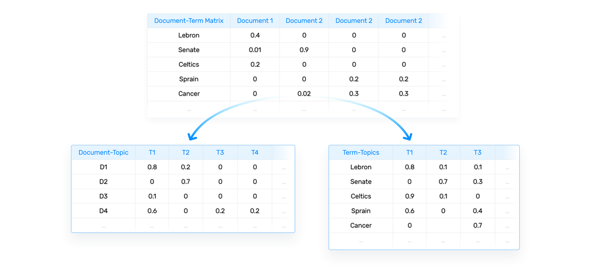

*The way these matrices are generated is by decomposing the document-term matrix into three matrices using a technique called **truncated SVD**. Firstly, **singular-value decomposition (SVD)** is a linear algebra algorithm for factorizing a matrix into the product of three matrices U *S* V.The important part is that the middle matrix S is a diagonal matrix of the singular values of the original matrix. For LSA, every one of the singular values represents a potential topic.*

*Truncated SVD* *selects the largest t singular values and keeps the first t columns of U and the first t rows of V, reducing the dimensionality of the original decomposition. t will be the number of topics that the algorithm finds, so it's a hyperparameter that will need tuning. The idea is that the most important topics are selected, and U is the document-topic matrix and V is the term-topic matrix.*

*The vectors that make up these matrices represent documents expressed with topics and terms expressed with topics; they can be measured with techniques such as **cosine similarity** to evaluate.*

## *Non-Negative Matrix Factorization (NMF)*

*Non-Negative Matrix Factorization (NMF) is an unsupervised technique so there are no labeling of topics that the model will be trained on. The way it works is that, NMF decomposes (or factorizes) high-dimensional vectors into a lower-dimensional representation. These lower-dimensional vectors are non-negative which also means their coefficients are non-negative.*

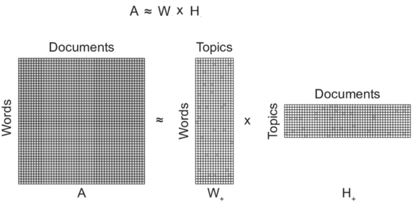

```python
#Importing required Libraries
import pandas as pd
import numpy as np
import matplotlib.pyplot as plt
import seaborn as sns

import re

# NLTK
import nltk
nltk.download('punkt')
nltk.download('stopwords')
nltk.download('wordnet')
from nltk.tokenize import word_tokenize
from nltk.stem import PorterStemmer
from nltk.corpus import stopwords

import string
from string import punctuation

import collections
from collections import Counter
```

```python
from nltk.corpus import brown

data = []

for fileid in brown.fileids():
    document = ' '.join(brown.words(fileid))
    data.append(document)

NO_DOCUMENTS = len(data)
print(NO_DOCUMENTS)
```

```
500
```

```python
# Cleaning and Tokenization of data

import re
from gensim import models, corpora
from nltk import word_tokenize
from nltk.corpus import stopwords

NUM_TOPICS = 10
STOPWORDS = stopwords.words('english')

def clean_text(text):
    tokenized_text = word_tokenize(text.lower())
    cleaned_text = [t for t in tokenized_text if t not in STOPWORDS and re.match('[a-zA-Z\-][a-zA-Z\-]{2,}', t)]
    return cleaned_text

# For gensim we need to tokenize the data and filter out stopwords
tokenized_data = []
for text in data:
    tokenized_data.append(clean_text(text))
```

```python
# Build a Dictionary - association word to numeric id
dictionary = corpora.Dictionary(tokenized_data)

# Transform the collection of texts to a numerical form
corpus = [dictionary.doc2bow(text) for text in tokenized_data]

# Have a look at how the 20th document looks like: [(word_id, count), ...]
# print(corpus[20])
# [(12, 3), (14, 1), (21, 1), (25, 5), (30, 2), (31, 5), (33, 1), (42, 1), (43, 2),  ...
```

## *LDA using gensim*

_[Reference](https://github.com/prateekjoshi565/latent_semantic_analysis/blob/master/Topic_Modeling_LSA.ipynb)_

```python
# Build the LDA model
lda_model = models.LdaModel(corpus=corpus, num_topics=NUM_TOPICS, id2word=dictionary)
```

```python
print("LDA Model:")

for idx in range(NUM_TOPICS):
    # Print the first 10 most representative topics
    print("Topic #%s:" % idx, lda_model.print_topic(idx, 10))
    print('\n')

print("=" * 20)
```

```
LDA Model:
Topic #0: 0.007*"one" + 0.005*"could" + 0.004*"would" + 0.004*"said" + 0.003*"time" + 0.003*"back" + 0.003*"man" + 0.003*"first" + 0.002*"two" + 0.002*"like"


Topic #1: 0.006*"would" + 0.005*"said" + 0.004*"one" + 0.004*"could" + 0.003*"time" + 0.003*"even" + 0.003*"like" + 0.003*"first" + 0.002*"man" + 0.002*"new"


Topic #2: 0.007*"one" + 0.004*"new" + 0.003*"would" + 0.003*"said" + 0.003*"also" + 0.003*"could" + 0.003*"may" + 0.003*"like" + 0.002*"first" + 0.002*"time"


Topic #3: 0.005*"one" + 0.003*"may" + 0.003*"would" + 0.003*"said" + 0.003*"two" + 0.003*"could" + 0.003*"new" + 0.003*"first" + 0.003*"time" + 0.003*"like"


Topic #4: 0.006*"would" + 0.006*"one" + 0.003*"said" + 0.003*"new" + 0.003*"man" + 0.002*"may" + 0.002*"made" + 0.002*"like" + 0.002*"two" + 0.002*"time"


Topic #5: 0.006*"one" + 0.005*"would" + 0.004*"time" + 0.003*"could" + 0.003*"new" + 0.003*"may" + 0.003*"even" + 0.003*"said" + 0.003*"two" + 0.002*"first"


Topic #6: 0.007*"one" + 0.006*"would" + 0.005*"said" + 0.004*"time" + 0.003*"made" + 0.003*"could" + 0.003*"may" + 0.003*"first" + 0.003*"man" + 0.003*"two"


Topic #7: 0.008*"one" + 0.005*"would" + 0.004*"could" + 0.003*"new" + 0.003*"time" + 0.003*"two" + 0.002*"first" + 0.002*"made" + 0.002*"even" + 0.002*"must"


Topic #8: 0.005*"one" + 0.005*"would" + 0.003*"could" + 0.003*"man" + 0.003*"first" + 0.003*"said" + 0.003*"new" + 0.002*"time" + 0.002*"may" + 0.002*"like"


Topic #9: 0.005*"would" + 0.005*"one" + 0.004*"said" + 0.003*"new" + 0.003*"two" + 0.003*"man" + 0.002*"could" + 0.002*"may" + 0.002*"like" + 0.002*"time"


====================
```

```python
### SAVE AND RE-USE the Model

# lda_model.save('lda_model.gensim')
# lda = gensim.models.LdaModel.load('lda_model.gensim')
```

```python
text = "The economy is working better than ever"
bow = dictionary.doc2bow(clean_text(text))

print(lda_model[bow])
```

```
[(0, 0.020011596), (1, 0.8198962), (2, 0.02001145), (3, 0.020011961), (4, 0.020010894), (5, 0.020011991), (6, 0.020011565), (7, 0.020010613), (8, 0.020010967), (9, 0.020012757)]
```

#### *Most Similar Sentences to the Test Sentence*

```python
from gensim import similarities

lda_index = similarities.MatrixSimilarity(lda_model[corpus])

# Let's perform some queries
similarities = lda_index[lda_model[bow]]

# Sort the similarities
similarities = sorted(enumerate(similarities), key=lambda item: -item[1])

# Top most similar documents:
print(similarities[:10])
# [(104, 0.87591344), (178, 0.86124849), (31, 0.8604598), (77, 0.84932965), (85, 0.84843522), (135, 0.84421808), (215, 0.84184396), (353, 0.84038532), (254, 0.83498049), (13, 0.82832891)]

# Let's see what's the most similar document
document_id, similarity = similarities[0]
print(data[document_id][:1000])
```

```
[(493, 0.99816585), (463, 0.99788904), (438, 0.99778414), (401, 0.997627), (410, 0.9975934), (395, 0.9975868), (397, 0.99756247), (261, 0.99755114), (126, 0.997532), (452, 0.9975267)]
Needless to say , I was furious at this unparalleled intrusion upon free enterprise . How dared they demand to `` snoop '' in private financial records , disbursements , confidential contracts and agreements ? ? `` It is as though '' , I said on the historic three-hour , coast-to-coast radio broadca…
```

```python
import pyLDAvis.gensim

pyLDAvis.enable_notebook()
panel = pyLDAvis.gensim.prepare(lda_model, corpus, dictionary)
panel

# When lambda = 1, the relevance score = P(word | topic k), in other words their frequency count.
```

[interactive chart not shown]

## *Compute Model Perplexity and Coherence Score*

*Model perplexity and topic coherence provide a convenient measure to judge how good a given topic model is. Topic coherence score, in particular, has been more helpful.*

```python
from gensim.models import CoherenceModel

# Compute Perplexity
print('\nPerplexity: ', lda_model.log_perplexity(corpus))  # a measure of how good the model is. lower the better.

# Compute Coherence Score
coherence_model_lda = CoherenceModel(model=lda_model, texts=tokenized_data, dictionary=dictionary, coherence='c_v')
coherence_lda = coherence_model_lda.get_coherence()
print('\nCoherence Score: ', coherence_lda)
```

```
Perplexity:  -9.849997532193864

Coherence Score:  0.27518499411255903
```

*To find no. of Topics in the documents use coherence score technique and select K with best coherence score.*

## *LSI using gensim*

```python
# Build the LSI model
lsi_model = models.LsiModel(corpus=corpus, num_topics=NUM_TOPICS, id2word=dictionary)
```

```python
print("LSI Model:")

for idx in range(NUM_TOPICS):
    # Print the first 10 most representative topics
    print("Topic #%s:" % idx, lsi_model.print_topic(idx, 10))
    print('\n')

print("=" * 20)
```

```
LSI Model:
Topic #0: -0.308*"one" + -0.280*"would" + -0.202*"said" + -0.175*"could" + -0.146*"time" + -0.144*"new" + -0.126*"man" + -0.125*"like" + -0.125*"two" + -0.120*"first"


Topic #1: -0.294*"said" + 0.219*"may" + 0.179*"state" + -0.176*"could" + -0.153*"would" + 0.143*"states" + 0.141*"new" + -0.140*"like" + -0.139*"back" + -0.105*"man"


Topic #2: -0.339*"said" + -0.338*"state" + 0.228*"one" + -0.191*"states" + -0.161*"year" + -0.152*"mrs." + -0.135*"would" + -0.132*"united" + -0.132*"federal" + -0.130*"government"


Topic #3: 0.263*"new" + 0.256*"mrs." + -0.154*"feed" + -0.151*"per" + 0.149*"world" + -0.145*"used" + 0.140*"church" + 0.118*"god" + 0.107*"life" + 0.101*"people"


Topic #4: 0.510*"mrs." + -0.236*"would" + -0.192*"states" + -0.154*"united" + -0.130*"could" + -0.123*"man" + -0.122*"state" + -0.110*"government" + 0.104*"year" + 0.100*"school"


Topic #5: -0.380*"feed" + 0.368*"would" + -0.276*"per" + -0.240*"state" + -0.129*"god" + -0.127*"daily" + -0.123*"man" + -0.121*"drug" + 0.116*"school" + -0.116*"name"


Topic #6: -0.267*"feed" + 0.262*"mrs." + -0.216*"per" + -0.181*"school" + -0.167*"would" + 0.162*"states" + 0.151*"state" + -0.144*"said" + 0.139*"united" + 0.135*"one"


Topic #7: -0.375*"mrs." + -0.280*"would" + 0.271*"state" + 0.223*"school" + -0.220*"feed" + 0.220*"said" + -0.144*"united" + -0.138*"per" + -0.105*"government" + 0.105*"education"


Topic #8: 0.370*"state" + 0.287*"mrs." + 0.279*"would" + -0.175*"new" + -0.158*"business" + -0.153*"united" + 0.153*"one" + -0.128*"development" + 0.127*"feed" + -0.116*"small"


Topic #9: 0.203*"may" + 0.195*"mrs." + -0.190*"new" + 0.185*"shall" + 0.173*"said" + 0.168*"united" + 0.156*"states" + 0.150*"school" + -0.147*"would" + 0.137*"form"


====================
```

```python
print(lsi_model[bow])
```

```
[(0, -0.09161628469558519), (1, -0.008675863124612474), (2, 0.016139250010745284), (3, 0.040823674958158244), (4, 0.015050194526253221), (5, -0.013395369625539647), (6, -0.02732364867480252), (7, 0.01689400960631306), (8, -0.05764094981511671), (9, -0.025222191914084695)]
```

## *LDA, LSA and NMF using sklearn*

```python
from sklearn.decomposition import NMF, LatentDirichletAllocation, TruncatedSVD
from sklearn.feature_extraction.text import CountVectorizer

NUM_TOPICS = 10

vectorizer = CountVectorizer(min_df=5, max_df=0.9,
                             stop_words='english', lowercase=True,
                             token_pattern='[a-zA-Z\-][a-zA-Z\-]{2,}')

data_vectorized = vectorizer.fit_transform(data)
```

```python
def print_topics(model, vectorizer, top_n=10):
    for idx, topic in enumerate(model.components_):
        print("Topic %d:" % (idx))
        print([(vectorizer.get_feature_names()[i], topic[i])
                        for i in topic.argsort()[:-top_n - 1:-1]])
```

```python
# Build a Latent Dirichlet Allocation Model
lda_model = LatentDirichletAllocation(n_components=NUM_TOPICS, max_iter=10, learning_method='online')
lda_Z = lda_model.fit_transform(data_vectorized)

print(lda_Z.shape)  # (NO_DOCUMENTS, NO_TOPICS)

print("=" * 20)

# Let's see how the first document in the corpus looks like in different topic spaces
print(lda_Z[0])

print("=" * 20)

print("LDA Model:")
print_topics(lda_model, vectorizer)
```

```
(500, 10)
====================
[1.05623906e-04 5.43066042e-01 1.05596690e-04 1.05615669e-04
 1.05622321e-04 4.56089078e-01 1.05610268e-04 1.05596758e-04
 1.05610809e-04 1.05603445e-04]
====================
LDA Model:
Topic 0:
[('boats', 35.67569250228177), ('boat', 23.238972369502495), ('said', 17.339129905074117), ('boating', 16.43532754882519), ('stein', 13.896437070825991), ('friday', 9.483896376923425), ('according', 8.717906848268138), ('property', 7.760466461135761), ('sept', 7.27506477372944), ('lake', 6.865245613…
Topic 1:
[('said', 765.0573614257191), ('new', 590.8601335136253), ('time', 443.53352684547934), ('mrs', 425.1289539484915), ('man', 412.2680725627749), ('years', 398.42254090156774), ('did', 393.98036606916395), ('like', 329.41880869072617), ('john', 300.32121439935247), ('day', 279.89994406978593)]
Topic 2:
[('new', 0.4260853421825713), ('said', 0.35792384870050575), ('mrs', 0.34727779362176614), ('time', 0.347023551689236), ('music', 0.32001384152412804), ('year', 0.28957798065654955), ('make', 0.276014655228849), ('city', 0.2634274752915426), ('little', 0.2629142243777688), ('american', 0.26006611853…
Topic 3:
[('used', 239.57616573383692), ('temperature', 121.36754755963241), ('surface', 118.68999076941859), ('time', 91.33332420340379), ('radiation', 89.71704752367454), ('use', 89.17392868339114), ('water', 86.46427139161112), ('data', 85.73924317761133), ('small', 79.34007195602271), ('high', 79.0617528…
Topic 4:
[('said', 1181.3327028968279), ('like', 820.9314290911246), ('man', 633.2123982729547), ('time', 583.5689509822423), ('just', 545.5479363411596), ('did', 481.43394285504166), ('little', 437.1331215313744), ('don', 432.61959868367506), ('got', 405.0830661587262), ('came', 398.33018793539173)]
Topic 5:
[('new', 574.6853213341759), ('state', 567.491765738882), ('states', 396.54046892220646), ('year', 378.76019013046346), ('government', 328.70075178109164), ('time', 321.90978436452843), ('united', 312.88691837409345), ('program', 311.7110271145226), ('general', 311.2862330448953), ('years', 294.9842…
Topic 6:
[('clay', 60.663186072280354), ('points', 48.10104699035425), ('point', 42.70082590196584), ('knife', 41.091913934123525), ('plane', 39.678286195280485), ('bridge', 36.151834665671224), ('pieces', 35.29120177914106), ('number', 35.08005833067156), ('surface', 34.4193424543338), ('place', 34.10639573…
Topic 7:
[('mrs', 1.067055831098455), ('new', 0.5836750556974145), ('said', 0.4874614191874436), ('years', 0.47644282367926), ('home', 0.45011600194339124), ('people', 0.40723719396525304), ('good', 0.4033974386649123), ('time', 0.3776046932235479), ('make', 0.3698229799266438), ('year', 0.35591807841271317)…
Topic 8:
[('world', 314.1472276870655), ('man', 216.6818570218148), ('life', 214.54938055104952), ('new', 187.8714902996264), ('human', 168.5548628251294), ('sense', 149.91337725369678), ('great', 148.92983881643548), ('history', 142.90931179783996), ('time', 141.4479977662081), ('people', 137.4170858364711)…
Topic 9:
[('meeting', 26.129980891966003), ('president', 25.903492261083397), ('khrushchev', 23.528876912545726), ('rome', 20.676210265679018), ('shore', 19.66645367759481), ('century', 18.01564019005461), ('kennedy', 17.373377639261346), ('premier', 13.098764014143088), ('soviet', 12.488783262548429), ('mos…
```

```python
# Build a Non-Negative Matrix Factorization Model
nmf_model = NMF(n_components=NUM_TOPICS)
nmf_Z = nmf_model.fit_transform(data_vectorized)

print(nmf_Z.shape)  # (NO_DOCUMENTS, NO_TOPICS)

print("=" * 20)

print(nmf_Z[0])

print("=" * 20)

print("NMF Model:")
print_topics(nmf_model, vectorizer)
```

```
(500, 10)
====================
[0.         0.         2.12208639 0.07711608 0.         0.54592154
 1.06692964 0.         0.         0.25395392]
====================
NMF Model:
Topic 0:
[('like', 5.590907141685668), ('man', 4.22552586441156), ('time', 3.8405865205539738), ('just', 3.3977197015389096), ('did', 3.3934225087008993), ('little', 2.921775965567192), ('said', 2.8186698603722022), ('know', 2.574350102518513), ('way', 2.453999721847028), ('don', 2.418241473605731)]
Topic 1:
[('new', 5.318618940883313), ('world', 3.917727373217859), ('life', 2.8430996579210057), ('man', 2.8210576219435004), ('people', 2.54093623629375), ('god', 2.1562365041876776), ('american', 2.096380761459353), ('church', 2.0939999456917118), ('great', 2.0107507165309113), ('social', 1.99288673500126…
Topic 2:
[('said', 12.873481894644652), ('city', 1.3815952069083013), ('house', 1.3746526867764122), ('new', 1.2677176209961665), ('home', 1.243104152104819), ('told', 1.2393691614914246), ('asked', 1.1473929155884675), ('president', 1.0076009628983846), ('police', 0.95626369972534), ('mike', 0.8382995464244…
Topic 3:
[('mrs', 11.831510052082775), ('miss', 1.7040021579828841), ('new', 1.2122399121211165), ('home', 1.1459331783200246), ('john', 1.0644718317129926), ('house', 0.9800787547254335), ('club', 0.9732117901416755), ('daughter', 0.9202724249033764), ('robert', 0.8266267132996333), ('chairman', 0.796847020…
Topic 4:
[('used', 3.5043071293626693), ('use', 2.0411020669771958), ('surface', 1.9281666011430094), ('number', 1.8504362128343004), ('feed', 1.7894484135448763), ('time', 1.7632134050752926), ('temperature', 1.660566473747923), ('water', 1.6152492774043041), ('data', 1.498437073024768), ('clay', 1.33374852…
Topic 5:
[('school', 5.658496055824295), ('education', 2.7746029727195123), ('schools', 2.5873558230649683), ('children', 2.1946955156249177), ('college', 2.156851578087033), ('vocational', 1.8368146394458333), ('training', 1.7146392877904235), ('students', 1.7011275313647567), ('high', 1.568893667669881), (…
Topic 6:
[('state', 10.770687433271613), ('federal', 3.37280431374302), ('states', 2.318763531650463), ('law', 2.081407604617752), ('policy', 1.5720565628638785), ('vehicles', 1.4497978753480643), ('rhode', 1.4037225695351343), ('court', 1.376405637964243), ('island', 1.3713039212453955), ('congress', 1.2302…
Topic 7:
[('united', 5.2890879160820985), ('states', 5.286791862879019), ('government', 3.4960913960362325), ('shall', 3.1607073626875986), ('section', 2.0478573406669507), ('act', 2.0032423254201004), ('agreement', 1.8543449731421588), ('secretary', 1.6866566102483729), ('india', 1.567285552125781), ('ameri…
Topic 8:
[('form', 4.5496001274491364), ('dictionary', 4.422672400113625), ('information', 4.318804907896127), ('text', 3.3271861664854936), ('cell', 2.853662263514451), ('forms', 2.7993105853509364), ('list', 1.9441499034715397), ('address', 1.7699296741746644), ('occurrence', 1.4535232490742753), ('cells',…
Topic 9:
[('year', 3.5299876145029625), ('new', 3.2484765666655577), ('business', 2.5549614111481547), ('tax', 1.7145417223716906), ('fiscal', 1.6889855330362684), ('costs', 1.6065736039715137), ('service', 1.526230445803656), ('cost', 1.4975582869700996), ('development', 1.4589841449283492), ('company', 1.4…
```

```python
# Build a Latent Semantic Indexing Model
lsi_model = TruncatedSVD(n_components=NUM_TOPICS)
lsi_Z = lsi_model.fit_transform(data_vectorized)

print(lsi_Z.shape)  # (NO_DOCUMENTS, NO_TOPICS)

print("=" * 20)

print(lsi_Z[0])

print("=" * 20)

print("LSI Model:")
print_topics(lsi_model, vectorizer)
print("=" * 20)
```

```
(500, 10)
====================
[ 23.30684298   1.59556584  21.81613842  -0.09309321   0.82147636
  11.6521915    3.60991189  -1.97861513   1.40603867 -14.92197185]
====================
LSI Model:
Topic 0:
[('said', 0.27373905235427154), ('new', 0.1942088301050115), ('time', 0.18634773276302025), ('man', 0.16422113179211742), ('like', 0.16151253480459296), ('did', 0.12741209402703566), ('years', 0.11440149232328024), ('just', 0.10896553400764532), ('way', 0.10626155352754466), ('state', 0.105466701750…
Topic 1:
[('state', 0.2224201294526208), ('states', 0.17249134134049407), ('new', 0.15871917450064776), ('united', 0.12269530079042953), ('government', 0.10980220036992862), ('year', 0.1078436518702185), ('program', 0.09501578417160764), ('development', 0.08704000483254752), ('federal', 0.08449683574800607),…
Topic 2:
[('said', 0.3662711678808547), ('state', 0.3595697998935612), ('mrs', 0.17931867101175153), ('states', 0.1757241080027133), ('year', 0.16289288393526927), ('federal', 0.13609293082751134), ('united', 0.11255017830014098), ('government', 0.110130777509767), ('tax', 0.11009491635663446), ('fiscal', 0.…
Topic 3:
[('mrs', 0.4727077211393931), ('new', 0.2502281318589499), ('church', 0.15085363539805963), ('members', 0.116940016351183), ('world', 0.11581134232186048), ('john', 0.10624005688311215), ('god', 0.09823190160243012), ('social', 0.09226324959761095), ('president', 0.08639599917098494), ('life', 0.082…
Topic 4:
[('mrs', 0.5017503097596002), ('used', 0.11176004014777763), ('school', 0.10127647173085087), ('year', 0.09342217783379161), ('information', 0.08459314023420704), ('home', 0.07838386979986912), ('miss', 0.07793712227424662), ('small', 0.07390782895909202), ('cost', 0.07287269785325165), ('high', 0.0…
Topic 5:
[('school', 0.38835040524429343), ('said', 0.21232064113005597), ('education', 0.1992824717323226), ('schools', 0.17995239227304183), ('vocational', 0.1409017312255191), ('children', 0.14008385018873065), ('college', 0.13947331493945433), ('training', 0.12279574991212358), ('students', 0.12068831551…
Topic 6:
[('state', 0.4064204724328168), ('mrs', 0.2820454900309693), ('form', 0.2069089847692914), ('dictionary', 0.17701834338595446), ('information', 0.15552404547476648), ('text', 0.1324870634820267), ('forms', 0.11892128631516906), ('cell', 0.11750508862410589), ('federal', 0.11170643526723012), ('law',…
Topic 7:
[('united', 0.2746892585497728), ('states', 0.22239999621476256), ('shall', 0.18644049652737488), ('government', 0.18481805442507218), ('mrs', 0.1830156092510513), ('school', 0.14308342943330596), ('act', 0.1192385899402868), ('section', 0.11854748503553916), ('agreement', 0.1164722430281746), ('ind…
Topic 8:
[('form', 0.31932754987154427), ('dictionary', 0.29777212899737865), ('information', 0.2896012702921124), ('text', 0.22512665725056008), ('year', 0.19375871963867977), ('cell', 0.18931590857626795), ('forms', 0.1858029327834458), ('tax', 0.15967064147437016), ('new', 0.14330111039176047), ('fiscal',…
Topic 9:
[('fiscal', 0.2597769173091987), ('year', 0.2488814087610948), ('school', 0.20654928370071735), ('tax', 0.17275415570879318), ('states', 0.1530342971069428), ('like', 0.1363361568003549), ('time', 0.10475646237245177), ('united', 0.09569918000200901), ('child', 0.08555669193848549), ('children', 0.0…
====================
```

```python
text = "The economy is working better than ever"
x = nmf_model.transform(vectorizer.transform([text]))[0]
print(x)
```

```
[0.00290538 0.         0.         0.         0.         0.00441239
 0.         0.         0.         0.00481356]
```

```python
from sklearn.metrics.pairwise import euclidean_distances

def most_similar(x, Z, top_n=5):
    dists = euclidean_distances(x.reshape(1, -1), Z)
    pairs = enumerate(dists[0])
    most_similar = sorted(pairs, key=lambda item: item[1])[:top_n]
    return most_similar

similarities = most_similar(x, nmf_Z)
document_id, similarity = similarities[0]
print(data[document_id][:1000])
```

```
Livery stable -- J. Vernon , prop. '' . Coaching had declined considerably by 1905 , but the sign was still there , near the old Wells Fargo building in San Francisco , creaking in the fog as it had for thirty years . John Vernon had had all the patronage he cared for -- he had prospered , but he co…
```

```python
import pyLDAvis.sklearn

pyLDAvis.enable_notebook()
panel = pyLDAvis.sklearn.prepare(lda_model, data_vectorized, vectorizer, mds='tsne')
panel
```

[interactive chart not shown]

*[Reference](https://stackabuse.com/python-for-nlp-topic-modeling/)* *[Very Good Reference](https://www.machinelearningplus.com/nlp/topic-modeling-gensim-python/#4whatdoesldado)*